# **Modelación del movimiento en ingeniería**

# Movimiento en una dimensión

### M. en C. Jonathan A. Urrutia Anguiano

### F1006B.218

## Cantidades dinámicas

Para describir el movimiento de una partícula, se emplea el vector posición $\vec{r}$, el cuál da una expresión para conocer en qué punto del espacio tridimencional se encuentra la partícula como función del tiempo $t$.

Es posible calcular los cambios de la posición al pasar el tiempo *calculando la derivada respecto al tiempo* de esta canidad, lo que determina la antidad física llamada *velocidad instantánea*. Al volver a derivar, se obtiene la relación con la *aceleración*.

En coordenadas cartesianas, la derivación respecto a tiempo se puede realizar componente a componente, es decir, se cumplen las siguientes expresiones:

$$ \vec{r} = (x (t),\; y(t),\; z(t)) \qquad\Longrightarrow \qquad\vec{v} = \dot{\vec{r}} = (\dot{x} (t),\; \dot{y}(t),\; \dot{z}(t)) \qquad\Longrightarrow \qquad\vec{a} = \ddot{\vec{r}} = (\ddot{x} (t),\; \ddot{y}(t),\; \ddot{z}(t)) $$

### Simplificando en una sola dimensión

Dado que en coordenadas cartesianas es posible realizar las derivaciones respecto al tiempo componente a componente, consideremos el caso unidimensional para analizar los casos donde:

- La velocidad es constante: **Movimiento rectilíneo uniforme (MRU)**
- La aceleración es constante: **Movimiento uniformemente acelerado (MUA)**

## Movimiento Rectilíneo Uniforme (MRU)

En el caso unidimensional podemos considerar a la coordenada $x(t)$ como la que describe a una partícula que puede moverse a lo largo de una línea recta. En este caso, su velocidad está dada por la expresión

$${v}(t) = \lim_{\Delta t\to 0} \dfrac{\Delta x(t)}{\Delta{t}} = \dv{x(t)}{t} $$

donde $\Delta x(t)/\Delta t = v_\text{ave}$ es la velocidad promedio.

Si consideramos el caso en el que la **velocidad es constante**, entonces ésta es igual a la velocidad promedio, por lo que se puede despejar la posición de la siguiente manera:

$$ v = \frac{\Delta x(t)}{\Delta t} = \frac{x(t)-x_0}{t-t_0} \qquad\Longrightarrow\qquad x(t) = x_0 + v (t - t_0) $$

Lo que corresponde a la ecuaciónd e una recta con oordenda al origen $x_0$, pendiente $v$ y desplazada $t_0$ unidades a la derecha. Notemos además que $v \equiv \text{cte}$ y por tanto $a = 0$.

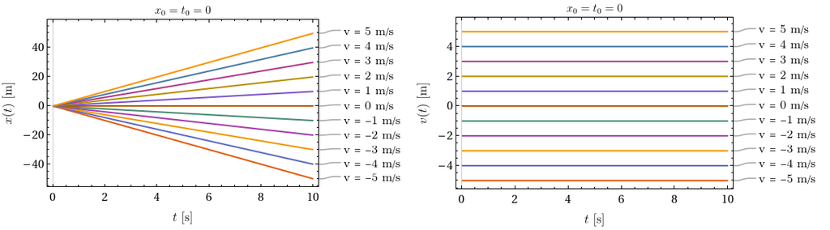

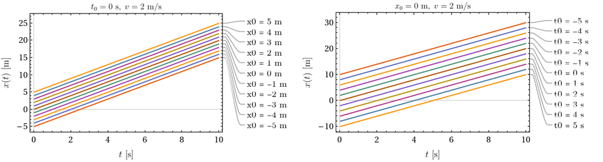

## Ejemplo:

Supongamos que, en primera aproximación, la línea 3 del Metro es una línea recta de 23 km de longitud entre las terminales Garibaldi y Constitución de 1927. Asumiento que los trenes no hacen paradas y dos de ellos salen al mismo tiempo de terminales opuestas, determina:

- En cuanto tiempo y en qué kilómetro se encuentran los trenes si el que sale de Garibaldi viaja a 60 km/hr y el otro a 80 km/hr.
- Si el tren que sale de Garibaldi lo hace a las 12:00 am, y el otro a las 12:20 ¿cómo se modifica la anterior respuesta?

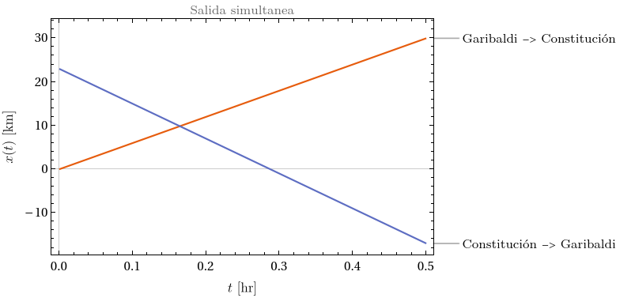

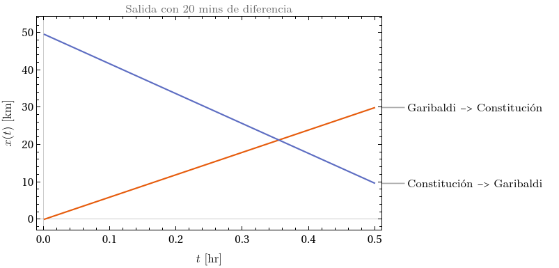

## Movimiento Uniformemente Acelerado (MUA)

De nuevo considerando el caso unidimensional, podemos estudiar la dinámica del sistema en un caso sencillo. Recordemos que la aceleración es la derivada respecto al tiempo de la velocidad, es decir que

$${a}(t) = \lim_{\Delta t\to 0} \dfrac{\Delta v(t)}{\Delta{t}} = \dv{v(t)}{t} $$

donde $\Delta v(t)/\Delta t = a_\text{ave}$ es la aceleración promedio.

Si consideramos el caso en el que la **aceleración es constante**, entonces ésta es igual a la aceleración promedio, por lo que se puede despejar la velocidad* de la siguiente manera:

$$ a = \frac{\Delta v(t)}{\Delta t} = \frac{v(t)-v_0}{t-t_0} \qquad\Longrightarrow\qquad v(t) = v_0 + a (t - t_0), $$

lo que corresponde a la ecuación de una recta con ordenda al origen $v_0$, pendiente $a$ y desplazada $t_0$ unidades a la derecha. Al realizar la integral respecto al tiempo de la velocidad se determina la posición $x(t)$ de una partícula. En el caso de MUA se tinene que

$$ x(t) - x_0 = \int_{t_0}^{t} v(t') \dd{t'} = v_0 (t-t_0) + \frac{1}{2} a (t - t_0)^2, $$

es decir, que el movimiento en este caso está descrito por una parábola.

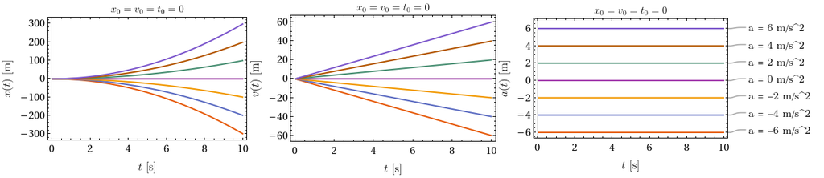

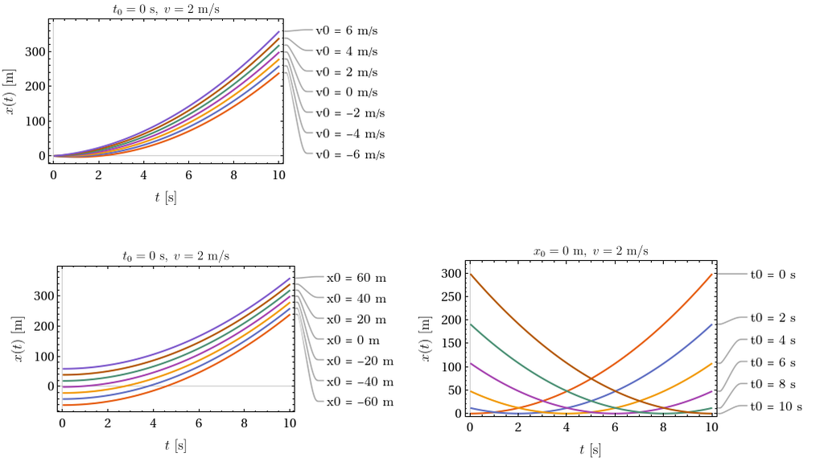

## Ejemplos:

- Se lanza una pelota hacia arriba con masa $m$ a una velocidad de $5$ m/s. ¿Cuánto tiempo tarda la pelota al suelo en llegar a la altura de la que fue lanzada?
- ¿Cuál es la altura máxima que alcanza la pelota?
- Si una segunda pelota se lanza sobre la misma linea, 0.5 segundos después de la primera con una velocidad de $4$ m/s ¿Encuanto tiempo y a qué altura se encuentran las pelota?
- Si queremos que la segunda pelota llegue al suelo al mismo tiempo que la segunda ¿Con qué velocidad debe lanzarse la segunda?

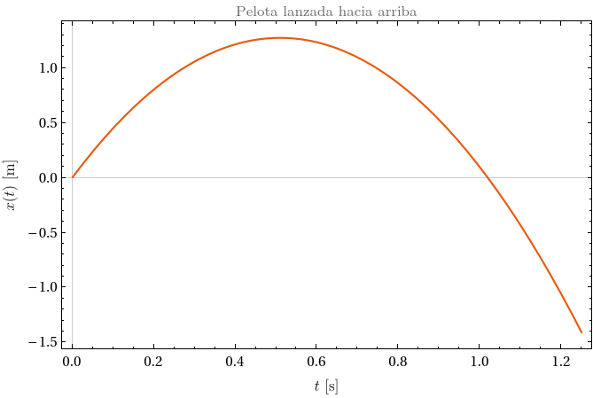

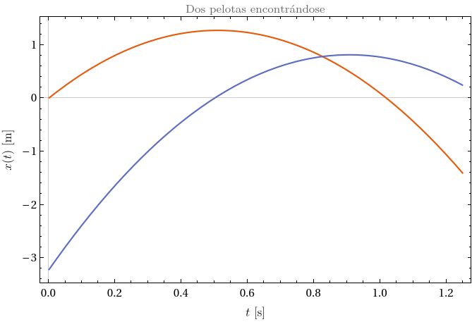

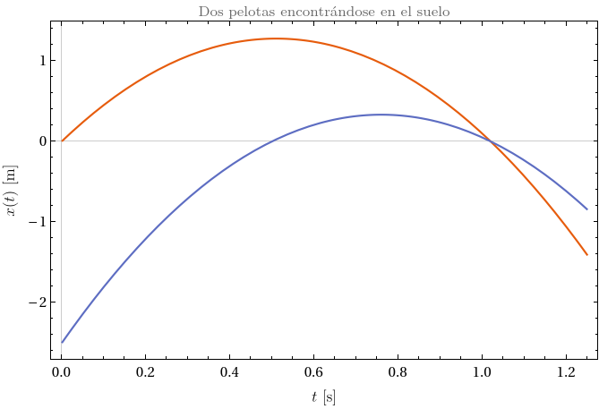